# Risk Factor Analysis

## Outcome Variable

**Outcome Variable:** y_rate_len

## Predictor Variables

**Intervention Variable:** single

**Adjustment Set:**

- arm
- W_mage
- W_fage
- meducyrs
- feducyrs
- W_mhtcm
- W_mwtkg
- W_mbmi
- delta_W_mage
- delta_W_fage
- delta_meducyrs
- delta_feducyrs
- delta_W_mhtcm
- delta_W_mwtkg
- delta_W_mbmi

## Stratifying Variables

The analysis was stratified on these variable(s):

- agecat
- studyid
- country

## Data Summary

| agecat | studyid | country | single | n_cell | n |
| --- | --- | --- | --- | --- | --- |
| 0-3 months | ki0047075b-MAL-ED | BANGLADESH | 0 | 244 | 244 |
| 0-3 months | ki1119695-PROBIT | BELARUS | 0 | 12251 | 12745 |
| 0-3 months | ki1119695-PROBIT | BELARUS | 1 | 494 | 12745 |
| 0-3 months | ki0047075b-MAL-ED | BRAZIL | 0 | 157 | 180 |
| 0-3 months | ki0047075b-MAL-ED | BRAZIL | 1 | 23 | 180 |
| 0-3 months | ki1135781-COHORTS | GUATEMALA | 0 | 632 | 676 |
| 0-3 months | ki1135781-COHORTS | GUATEMALA | 1 | 44 | 676 |
| 0-3 months | ki0047075b-MAL-ED | INDIA | 0 | 200 | 200 |
| 0-3 months | ki1135781-COHORTS | INDIA | 0 | 4655 | 4662 |
| 0-3 months | ki1135781-COHORTS | INDIA | 1 | 7 | 4662 |
| 0-3 months | ki0047075b-MAL-ED | NEPAL | 0 | 175 | 175 |
| 0-3 months | ki0047075b-MAL-ED | PERU | 0 | 238 | 271 |
| 0-3 months | ki0047075b-MAL-ED | PERU | 1 | 33 | 271 |
| 0-3 months | ki0047075b-MAL-ED | SOUTH AFRICA | 0 | 131 | 229 |
| 0-3 months | ki0047075b-MAL-ED | SOUTH AFRICA | 1 | 98 | 229 |
| 0-3 months | ki0047075b-MAL-ED | TANZANIA, UNITED REPUBLIC OF | 0 | 220 | 229 |
| 0-3 months | ki0047075b-MAL-ED | TANZANIA, UNITED REPUBLIC OF | 1 | 9 | 229 |
| 0-3 months | ki1126311-ZVITAMBO | ZIMBABWE | 0 | 7344 | 7835 |
| 0-3 months | ki1126311-ZVITAMBO | ZIMBABWE | 1 | 491 | 7835 |
| 3-6 months | ki0047075b-MAL-ED | BANGLADESH | 0 | 231 | 231 |
| 3-6 months | ki1119695-PROBIT | BELARUS | 0 | 12773 | 13309 |
| 3-6 months | ki1119695-PROBIT | BELARUS | 1 | 536 | 13309 |
| 3-6 months | ki0047075b-MAL-ED | BRAZIL | 0 | 178 | 208 |
| 3-6 months | ki0047075b-MAL-ED | BRAZIL | 1 | 30 | 208 |
| 3-6 months | ki1135781-COHORTS | GUATEMALA | 0 | 696 | 754 |
| 3-6 months | ki1135781-COHORTS | GUATEMALA | 1 | 58 | 754 |
| 3-6 months | ki0047075b-MAL-ED | INDIA | 0 | 227 | 227 |
| 3-6 months | ki1135781-COHORTS | INDIA | 0 | 4711 | 4719 |
| 3-6 months | ki1135781-COHORTS | INDIA | 1 | 8 | 4719 |
| 3-6 months | ki0047075b-MAL-ED | NEPAL | 0 | 233 | 233 |

[output cut: 57 more lines]

The following strata were considered:

- agecat: 0-3 months, studyid: ki0047075b-MAL-ED, country: BANGLADESH
- agecat: 0-3 months, studyid: ki0047075b-MAL-ED, country: BRAZIL
- agecat: 0-3 months, studyid: ki0047075b-MAL-ED, country: INDIA
- agecat: 0-3 months, studyid: ki0047075b-MAL-ED, country: NEPAL
- agecat: 0-3 months, studyid: ki0047075b-MAL-ED, country: PERU
- agecat: 0-3 months, studyid: ki0047075b-MAL-ED, country: SOUTH AFRICA
- agecat: 0-3 months, studyid: ki0047075b-MAL-ED, country: TANZANIA, UNITED REPUBLIC OF
- agecat: 0-3 months, studyid: ki1119695-PROBIT, country: BELARUS
- agecat: 0-3 months, studyid: ki1126311-ZVITAMBO, country: ZIMBABWE
- agecat: 0-3 months, studyid: ki1135781-COHORTS, country: GUATEMALA
- agecat: 0-3 months, studyid: ki1135781-COHORTS, country: INDIA
- agecat: 12-24 months, studyid: ki0047075b-MAL-ED, country: BANGLADESH
- agecat: 12-24 months, studyid: ki0047075b-MAL-ED, country: BRAZIL
- agecat: 12-24 months, studyid: ki0047075b-MAL-ED, country: INDIA
- agecat: 12-24 months, studyid: ki0047075b-MAL-ED, country: NEPAL
- agecat: 12-24 months, studyid: ki0047075b-MAL-ED, country: PERU
- agecat: 12-24 months, studyid: ki0047075b-MAL-ED, country: SOUTH AFRICA
- agecat: 12-24 months, studyid: ki0047075b-MAL-ED, country: TANZANIA, UNITED REPUBLIC OF
- agecat: 12-24 months, studyid: ki1066203-TanzaniaChild2, country: TANZANIA, UNITED REPUBLIC OF
- agecat: 12-24 months, studyid: ki1119695-PROBIT, country: BELARUS
- agecat: 12-24 months, studyid: ki1126311-ZVITAMBO, country: ZIMBABWE
- agecat: 12-24 months, studyid: ki1135781-COHORTS, country: GUATEMALA
- agecat: 12-24 months, studyid: ki1135781-COHORTS, country: INDIA
- agecat: 12-24 months, studyid: ki1135781-COHORTS, country: PHILIPPINES
- agecat: 3-6 months, studyid: ki0047075b-MAL-ED, country: BANGLADESH
- agecat: 3-6 months, studyid: ki0047075b-MAL-ED, country: BRAZIL
- agecat: 3-6 months, studyid: ki0047075b-MAL-ED, country: INDIA
- agecat: 3-6 months, studyid: ki0047075b-MAL-ED, country: NEPAL
- agecat: 3-6 months, studyid: ki0047075b-MAL-ED, country: PERU
- agecat: 3-6 months, studyid: ki0047075b-MAL-ED, country: SOUTH AFRICA
- agecat: 3-6 months, studyid: ki0047075b-MAL-ED, country: TANZANIA, UNITED REPUBLIC OF
- agecat: 3-6 months, studyid: ki1066203-TanzaniaChild2, country: TANZANIA, UNITED REPUBLIC OF
- agecat: 3-6 months, studyid: ki1119695-PROBIT, country: BELARUS
- agecat: 3-6 months, studyid: ki1126311-ZVITAMBO, country: ZIMBABWE
- agecat: 3-6 months, studyid: ki1135781-COHORTS, country: GUATEMALA
- agecat: 3-6 months, studyid: ki1135781-COHORTS, country: INDIA
- agecat: 6-12 months, studyid: ki0047075b-MAL-ED, country: BANGLADESH
- agecat: 6-12 months, studyid: ki0047075b-MAL-ED, country: BRAZIL
- agecat: 6-12 months, studyid: ki0047075b-MAL-ED, country: INDIA
- agecat: 6-12 months, studyid: ki0047075b-MAL-ED, country: NEPAL
- agecat: 6-12 months, studyid: ki0047075b-MAL-ED, country: PERU
- agecat: 6-12 months, studyid: ki0047075b-MAL-ED, country: SOUTH AFRICA
- agecat: 6-12 months, studyid: ki0047075b-MAL-ED, country: TANZANIA, UNITED REPUBLIC OF
- agecat: 6-12 months, studyid: ki1066203-TanzaniaChild2, country: TANZANIA, UNITED REPUBLIC OF
- agecat: 6-12 months, studyid: ki1112895-Guatemala BSC, country: GUATEMALA
- agecat: 6-12 months, studyid: ki1119695-PROBIT, country: BELARUS
- agecat: 6-12 months, studyid: ki1126311-ZVITAMBO, country: ZIMBABWE
- agecat: 6-12 months, studyid: ki1135781-COHORTS, country: GUATEMALA
- agecat: 6-12 months, studyid: ki1135781-COHORTS, country: INDIA
- agecat: 6-12 months, studyid: ki1135781-COHORTS, country: PHILIPPINES

## Methods Detail

We’re interested in the causal parameters $E[Y_a]$ for all values of $a \in \mathcal{A}$. These parameters represent the mean outcome if, possibly contrary to fact, we intervened to set all units to have $A=a$. Under the randomization and positivity assumptions, these are identified by the statistical parameters $\psi_a=E_W[E_{Y|A,W}(Y|A=a,W)]$. In addition, we’re interested in the mean of $Y$, $E[Y]$ under no intervention (the observed mean). We will estimate these parameters by using SuperLearner to fit the relevant likelihood factors – $E_{Y|A,W}(Y|A=a,W)$ and $p(A=a|W)$, and then updating our likelihood fit using a joint TMLE.

For unadjusted analyses ($W=\{\}$), initial likelihoods were estimated using Lrnr_glm to estimate the simple $E(Y|A)$ and Lrnr_mean to estimate $p(A)$. For adjusted analyses, a small library containing Lrnr_glmnet, Lrnr_xgboost, and Lrnr_mean was used.

Having estimated these parameters, we will then use the delta method to estimate relative risks and attributable risks relative to a prespecified baseline level of $A$.

[output not shown]

[output cut: 2049 more lines]

[output not shown]

# Results Detail

## Results Plots

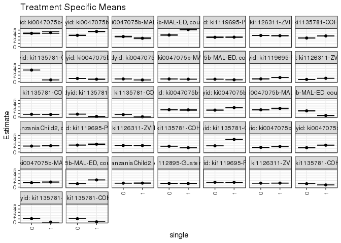

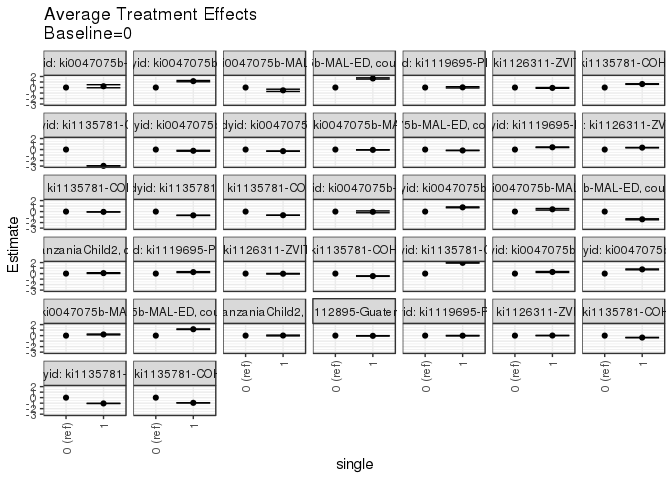

## Results Table

### Parameter: TSM

| agecat | studyid | country | intervention_level | baseline_level | estimate | ci_lower | ci_upper |
| --- | --- | --- | --- | --- | --- | --- | --- |
| 0-3 months | ki0047075b-MAL-ED | BRAZIL | 0 | NA | 4.0209447 | 3.9128859 | 4.1290034 |
| 0-3 months | ki0047075b-MAL-ED | BRAZIL | 1 | NA | 4.2530901 | 3.9941248 | 4.5120555 |
| 0-3 months | ki0047075b-MAL-ED | PERU | 0 | NA | 3.4234237 | 3.3537424 | 3.4931051 |
| 0-3 months | ki0047075b-MAL-ED | PERU | 1 | NA | 4.5787527 | 4.5126529 | 4.6448525 |
| 0-3 months | ki0047075b-MAL-ED | SOUTH AFRICA | 0 | NA | 3.0496733 | 2.9405593 | 3.1587873 |
| 0-3 months | ki0047075b-MAL-ED | SOUTH AFRICA | 1 | NA | 2.5372712 | 2.4051303 | 2.6694121 |
| 0-3 months | ki0047075b-MAL-ED | TANZANIA, UNITED REPUBLIC OF | 0 | NA | 3.5092094 | 3.4318439 | 3.5865750 |
| 0-3 months | ki0047075b-MAL-ED | TANZANIA, UNITED REPUBLIC OF | 1 | NA | 5.1529179 | 5.0788637 | 5.2269721 |
| 0-3 months | ki1119695-PROBIT | BELARUS | 0 | NA | 2.8311191 | 2.7199917 | 2.9422465 |
| 0-3 months | ki1119695-PROBIT | BELARUS | 1 | NA | 2.8600508 | 2.7759035 | 2.9441980 |
| 0-3 months | ki1126311-ZVITAMBO | ZIMBABWE | 0 | NA | 3.3789535 | 3.3576067 | 3.4003003 |
| 0-3 months | ki1126311-ZVITAMBO | ZIMBABWE | 1 | NA | 3.3107145 | 3.2421512 | 3.3792778 |
| 0-3 months | ki1135781-COHORTS | GUATEMALA | 0 | NA | 2.6094324 | 2.5634953 | 2.6553695 |
| 0-3 months | ki1135781-COHORTS | GUATEMALA | 1 | NA | 3.2382532 | 3.2085275 | 3.2679790 |
| 0-3 months | ki1135781-COHORTS | INDIA | 0 | NA | 3.5325376 | 3.5156469 | 3.5494283 |
| 0-3 months | ki1135781-COHORTS | INDIA | 1 | NA | 0.5650513 | 0.5534732 | 0.5766295 |
| 3-6 months | ki0047075b-MAL-ED | BRAZIL | 0 | NA | 2.1604797 | 2.0735441 | 2.2474154 |
| 3-6 months | ki0047075b-MAL-ED | BRAZIL | 1 | NA | 2.1109090 | 1.9694360 | 2.2523820 |
| 3-6 months | ki0047075b-MAL-ED | PERU | 0 | NA | 2.0386329 | 1.9737326 | 2.1035331 |
| 3-6 months | ki0047075b-MAL-ED | PERU | 1 | NA | 2.8076080 | 2.7514737 | 2.8637423 |
| 3-6 months | ki0047075b-MAL-ED | SOUTH AFRICA | 0 | NA | 2.1376399 | 2.0633657 | 2.2119140 |
| 3-6 months | ki0047075b-MAL-ED | SOUTH AFRICA | 1 | NA | 2.5490105 | 2.4476930 | 2.6503280 |
| 3-6 months | ki0047075b-MAL-ED | TANZANIA, UNITED REPUBLIC OF | 0 | NA | 1.8174579 | 1.7490609 | 1.8858550 |
| 3-6 months | ki0047075b-MAL-ED | TANZANIA, UNITED REPUBLIC OF | 1 | NA | 0.4138454 | 0.3604645 | 0.4672262 |
| 3-6 months | ki1066203-TanzaniaChild2 | TANZANIA, UNITED REPUBLIC OF | 0 | NA | 1.7904130 | 1.7533411 | 1.8274850 |
| 3-6 months | ki1066203-TanzaniaChild2 | TANZANIA, UNITED REPUBLIC OF | 1 | NA | 1.8771415 | 1.8130749 | 1.9412080 |
| 3-6 months | ki1119695-PROBIT | BELARUS | 0 | NA | 2.0860004 | 2.0453213 | 2.1266796 |
| 3-6 months | ki1119695-PROBIT | BELARUS | 1 | NA | 2.3582301 | 2.2837738 | 2.4326865 |
| 3-6 months | ki1126311-ZVITAMBO | ZIMBABWE | 0 | NA | 1.9713642 | 1.9508163 | 1.9919122 |
| 3-6 months | ki1126311-ZVITAMBO | ZIMBABWE | 1 | NA | 1.9469892 | 1.8939046 | 2.0000738 |
| 3-6 months | ki1135781-COHORTS | GUATEMALA | 0 | NA | 1.7427364 | 1.7108305 | 1.7746423 |
| 3-6 months | ki1135781-COHORTS | GUATEMALA | 1 | NA | 1.2904639 | 1.2534382 | 1.3274896 |
| 3-6 months | ki1135781-COHORTS | INDIA | 0 | NA | 1.8569731 | 1.8429514 | 1.8709947 |
| 3-6 months | ki1135781-COHORTS | INDIA | 1 | NA | 3.8091211 | 3.8010179 | 3.8172244 |
| 6-12 months | ki0047075b-MAL-ED | BRAZIL | 0 | NA | 1.3851019 | 1.3419109 | 1.4282928 |
| 6-12 months | ki0047075b-MAL-ED | BRAZIL | 1 | NA | 1.6786228 | 1.5912130 | 1.7660325 |
| 6-12 months | ki0047075b-MAL-ED | PERU | 0 | NA | 1.2971385 | 1.2528882 | 1.3413888 |
| 6-12 months | ki0047075b-MAL-ED | PERU | 1 | NA | 2.0610973 | 2.0176865 | 2.1045080 |
| 6-12 months | ki0047075b-MAL-ED | SOUTH AFRICA | 0 | NA | 1.3199108 | 1.2777121 | 1.3621095 |
| 6-12 months | ki0047075b-MAL-ED | SOUTH AFRICA | 1 | NA | 1.5314411 | 1.4777180 | 1.5851643 |
| 6-12 months | ki0047075b-MAL-ED | TANZANIA, UNITED REPUBLIC OF | 0 | NA | 1.0068543 | 0.9691964 | 1.0445123 |
| 6-12 months | ki0047075b-MAL-ED | TANZANIA, UNITED REPUBLIC OF | 1 | NA | 2.1674117 | 2.1389824 | 2.1958410 |
| 6-12 months | ki1066203-TanzaniaChild2 | TANZANIA, UNITED REPUBLIC OF | 0 | NA | 1.1952309 | 1.1727124 | 1.2177494 |
| 6-12 months | ki1066203-TanzaniaChild2 | TANZANIA, UNITED REPUBLIC OF | 1 | NA | 1.2122134 | 1.1445265 | 1.2799003 |
| 6-12 months | ki1112895-Guatemala BSC | GUATEMALA | 0 | NA | 1.1106819 | 1.0792675 | 1.1420963 |
| 6-12 months | ki1112895-Guatemala BSC | GUATEMALA | 1 | NA | 1.0714585 | 1.0333606 | 1.1095565 |
| 6-12 months | ki1119695-PROBIT | BELARUS | 0 | NA | 1.4767438 | 1.4392687 | 1.5142190 |
| 6-12 months | ki1119695-PROBIT | BELARUS | 1 | NA | 1.4628422 | 1.4238469 | 1.5018375 |
| 6-12 months | ki1126311-ZVITAMBO | ZIMBABWE | 0 | NA | 1.1983781 | 1.1871613 | 1.2095949 |
| 6-12 months | ki1126311-ZVITAMBO | ZIMBABWE | 1 | NA | 1.2149460 | 1.1898197 | 1.2400724 |
| 6-12 months | ki1135781-COHORTS | GUATEMALA | 0 | NA | 1.0053879 | 0.9873753 | 1.0234004 |
| 6-12 months | ki1135781-COHORTS | GUATEMALA | 1 | NA | 0.6532731 | 0.6227385 | 0.6838076 |
| 6-12 months | ki1135781-COHORTS | INDIA | 0 | NA | 1.0834711 | 1.0737783 | 1.0931640 |
| 6-12 months | ki1135781-COHORTS | INDIA | 1 | NA | 0.0317128 | 0.0274760 | 0.0359495 |
| 6-12 months | ki1135781-COHORTS | PHILIPPINES | 0 | NA | 1.0577224 | 1.0453494 | 1.0700953 |
| 6-12 months | ki1135781-COHORTS | PHILIPPINES | 1 | NA | 0.1157653 | 0.1084113 | 0.1231193 |
| 12-24 months | ki0047075b-MAL-ED | BRAZIL | 0 | NA | 0.9899289 | 0.9570213 | 1.0228365 |
| 12-24 months | ki0047075b-MAL-ED | BRAZIL | 1 | NA | 0.7623008 | 0.6939452 | 0.8306564 |
| 12-24 months | ki0047075b-MAL-ED | PERU | 0 | NA | 0.8444501 | 0.8239750 | 0.8649253 |
| 12-24 months | ki0047075b-MAL-ED | PERU | 1 | NA | 0.5547231 | 0.5352039 | 0.5742424 |
| 12-24 months | ki0047075b-MAL-ED | SOUTH AFRICA | 0 | NA | 0.8338327 | 0.8131211 | 0.8545443 |
| 12-24 months | ki0047075b-MAL-ED | SOUTH AFRICA | 1 | NA | 0.7739085 | 0.7512292 | 0.7965879 |
| 12-24 months | ki0047075b-MAL-ED | TANZANIA, UNITED REPUBLIC OF | 0 | NA | 0.7700351 | 0.7464397 | 0.7936305 |
| 12-24 months | ki0047075b-MAL-ED | TANZANIA, UNITED REPUBLIC OF | 1 | NA | 0.6042936 | 0.5762206 | 0.6323665 |
| 12-24 months | ki1119695-PROBIT | BELARUS | 0 | NA | 0.8628643 | 0.8096238 | 0.9161047 |
| 12-24 months | ki1119695-PROBIT | BELARUS | 1 | NA | 1.2734857 | 1.2566334 | 1.2903381 |
| 12-24 months | ki1126311-ZVITAMBO | ZIMBABWE | 0 | NA | 0.7058719 | 0.6785698 | 0.7331740 |
| 12-24 months | ki1126311-ZVITAMBO | ZIMBABWE | 1 | NA | 1.0527947 | 1.0312807 | 1.0743086 |
| 12-24 months | ki1135781-COHORTS | GUATEMALA | 0 | NA | 0.7822780 | 0.7711449 | 0.7934112 |
| 12-24 months | ki1135781-COHORTS | GUATEMALA | 1 | NA | 0.7249874 | 0.7173748 | 0.7325999 |
| 12-24 months | ki1135781-COHORTS | INDIA | 0 | NA | 0.8192760 | 0.8133741 | 0.8251778 |
| 12-24 months | ki1135781-COHORTS | INDIA | 1 | NA | 0.1306120 | 0.1270902 | 0.1341338 |
| 12-24 months | ki1135781-COHORTS | PHILIPPINES | 0 | NA | 0.6964300 | 0.6886336 | 0.7042265 |
| 12-24 months | ki1135781-COHORTS | PHILIPPINES | 1 | NA | 0.0323332 | 0.0270026 | 0.0376639 |

### Parameter: E(Y)

| agecat | studyid | country | intervention_level | baseline_level | estimate | ci_lower | ci_upper |
| --- | --- | --- | --- | --- | --- | --- | --- |
| 0-3 months | ki0047075b-MAL-ED | BRAZIL | NA | NA | 4.0509714 | 3.9492443 | 4.1526985 |
| 0-3 months | ki0047075b-MAL-ED | PERU | NA | NA | 3.3158605 | 3.2526447 | 3.3790763 |
| 0-3 months | ki0047075b-MAL-ED | SOUTH AFRICA | NA | NA | 3.4451859 | 3.3559092 | 3.5344627 |
| 0-3 months | ki0047075b-MAL-ED | TANZANIA, UNITED REPUBLIC OF | NA | NA | 3.4816904 | 3.4044928 | 3.5588880 |
| 0-3 months | ki1119695-PROBIT | BELARUS | NA | NA | 2.8355739 | 2.7218468 | 2.9493011 |
| 0-3 months | ki1126311-ZVITAMBO | ZIMBABWE | NA | NA | 3.3717033 | 3.3508142 | 3.3925924 |
| 0-3 months | ki1135781-COHORTS | GUATEMALA | NA | NA | 2.6198322 | 2.5745000 | 2.6651643 |
| 0-3 months | ki1135781-COHORTS | INDIA | NA | NA | 3.5323185 | 3.5154593 | 3.5491778 |
| 3-6 months | ki0047075b-MAL-ED | BRAZIL | NA | NA | 2.1478156 | 2.0686357 | 2.2269955 |
| 3-6 months | ki0047075b-MAL-ED | PERU | NA | NA | 2.0183213 | 1.9525900 | 2.0840526 |
| 3-6 months | ki0047075b-MAL-ED | SOUTH AFRICA | NA | NA | 1.9811941 | 1.9001209 | 2.0622672 |
| 3-6 months | ki0047075b-MAL-ED | TANZANIA, UNITED REPUBLIC OF | NA | NA | 1.8300902 | 1.7622436 | 1.8979368 |
| 3-6 months | ki1066203-TanzaniaChild2 | TANZANIA, UNITED REPUBLIC OF | NA | NA | 1.7925022 | 1.7566242 | 1.8283801 |
| 3-6 months | ki1119695-PROBIT | BELARUS | NA | NA | 2.0914863 | 2.0503474 | 2.1326251 |
| 3-6 months | ki1126311-ZVITAMBO | ZIMBABWE | NA | NA | 1.9751041 | 1.9551098 | 1.9950984 |
| 3-6 months | ki1135781-COHORTS | GUATEMALA | NA | NA | 1.7546801 | 1.7230708 | 1.7862894 |
| 3-6 months | ki1135781-COHORTS | INDIA | NA | NA | 1.8572663 | 1.8432699 | 1.8712628 |
| 6-12 months | ki0047075b-MAL-ED | BRAZIL | NA | NA | 1.3863464 | 1.3400121 | 1.4326807 |
| 6-12 months | ki0047075b-MAL-ED | PERU | NA | NA | 1.2102315 | 1.1775158 | 1.2429472 |
| 6-12 months | ki0047075b-MAL-ED | SOUTH AFRICA | NA | NA | 1.1895267 | 1.1483723 | 1.2306812 |
| 6-12 months | ki0047075b-MAL-ED | TANZANIA, UNITED REPUBLIC OF | NA | NA | 1.0019524 | 0.9648566 | 1.0390481 |
| 6-12 months | ki1066203-TanzaniaChild2 | TANZANIA, UNITED REPUBLIC OF | NA | NA | 1.1968182 | 1.1752193 | 1.2184170 |
| 6-12 months | ki1112895-Guatemala BSC | GUATEMALA | NA | NA | 1.1080731 | 1.0769747 | 1.1391716 |
| 6-12 months | ki1119695-PROBIT | BELARUS | NA | NA | 1.4709224 | 1.4326640 | 1.5091808 |
| 6-12 months | ki1126311-ZVITAMBO | ZIMBABWE | NA | NA | 1.1980807 | 1.1871310 | 1.2090305 |
| 6-12 months | ki1135781-COHORTS | GUATEMALA | NA | NA | 1.0157051 | 0.9977618 | 1.0336483 |
| 6-12 months | ki1135781-COHORTS | INDIA | NA | NA | 1.0833934 | 1.0737340 | 1.0930527 |
| 6-12 months | ki1135781-COHORTS | PHILIPPINES | NA | NA | 1.0669587 | 1.0547088 | 1.0792086 |
| 12-24 months | ki0047075b-MAL-ED | BRAZIL | NA | NA | 0.9816245 | 0.9508764 | 1.0123725 |
| 12-24 months | ki0047075b-MAL-ED | PERU | NA | NA | 0.8463453 | 0.8256453 | 0.8670453 |
| 12-24 months | ki0047075b-MAL-ED | SOUTH AFRICA | NA | NA | 0.8699064 | 0.8475321 | 0.8922808 |
| 12-24 months | ki0047075b-MAL-ED | TANZANIA, UNITED REPUBLIC OF | NA | NA | 0.7663111 | 0.7428636 | 0.7897586 |
| 12-24 months | ki1119695-PROBIT | BELARUS | NA | NA | 0.8601486 | 0.8069287 | 0.9133686 |
| 12-24 months | ki1126311-ZVITAMBO | ZIMBABWE | NA | NA | 0.7099126 | 0.6840087 | 0.7358165 |
| 12-24 months | ki1135781-COHORTS | GUATEMALA | NA | NA | 0.7791030 | 0.7680096 | 0.7901963 |
| 12-24 months | ki1135781-COHORTS | INDIA | NA | NA | 0.8192072 | 0.8133209 | 0.8250935 |
| 12-24 months | ki1135781-COHORTS | PHILIPPINES | NA | NA | 0.7055690 | 0.6981801 | 0.7129578 |

### Parameter: ATE

| agecat | studyid | country | intervention_level | baseline_level | estimate | ci_lower | ci_upper |
| --- | --- | --- | --- | --- | --- | --- | --- |
| 0-3 months | ki0047075b-MAL-ED | BRAZIL | 0 | 0 | 0.0000000 | 0.0000000 | 0.0000000 |
| 0-3 months | ki0047075b-MAL-ED | BRAZIL | 1 | 0 | 0.2321455 | -0.0451545 | 0.5094454 |
| 0-3 months | ki0047075b-MAL-ED | PERU | 0 | 0 | 0.0000000 | 0.0000000 | 0.0000000 |
| 0-3 months | ki0047075b-MAL-ED | PERU | 1 | 0 | 1.1553290 | 1.0411280 | 1.2695300 |
| 0-3 months | ki0047075b-MAL-ED | SOUTH AFRICA | 0 | 0 | 0.0000000 | 0.0000000 | 0.0000000 |
| 0-3 months | ki0047075b-MAL-ED | SOUTH AFRICA | 1 | 0 | -0.5124021 | -0.7192601 | -0.3055441 |
| 0-3 months | ki0047075b-MAL-ED | TANZANIA, UNITED REPUBLIC OF | 0 | 0 | 0.0000000 | 0.0000000 | 0.0000000 |
| 0-3 months | ki0047075b-MAL-ED | TANZANIA, UNITED REPUBLIC OF | 1 | 0 | 1.6437085 | 1.5307375 | 1.7566795 |
| 0-3 months | ki1119695-PROBIT | BELARUS | 0 | 0 | 0.0000000 | 0.0000000 | 0.0000000 |
| 0-3 months | ki1119695-PROBIT | BELARUS | 1 | 0 | 0.0289317 | -0.0835268 | 0.1413901 |
| 0-3 months | ki1126311-ZVITAMBO | ZIMBABWE | 0 | 0 | 0.0000000 | 0.0000000 | 0.0000000 |
| 0-3 months | ki1126311-ZVITAMBO | ZIMBABWE | 1 | 0 | -0.0682389 | -0.1397547 | 0.0032768 |
| 0-3 months | ki1135781-COHORTS | GUATEMALA | 0 | 0 | 0.0000000 | 0.0000000 | 0.0000000 |
| 0-3 months | ki1135781-COHORTS | GUATEMALA | 1 | 0 | 0.6288208 | 0.5760280 | 0.6816136 |
| 0-3 months | ki1135781-COHORTS | INDIA | 0 | 0 | 0.0000000 | 0.0000000 | 0.0000000 |
| 0-3 months | ki1135781-COHORTS | INDIA | 1 | 0 | -2.9674862 | -2.9879549 | -2.9470176 |
| 3-6 months | ki0047075b-MAL-ED | BRAZIL | 0 | 0 | 0.0000000 | 0.0000000 | 0.0000000 |
| 3-6 months | ki0047075b-MAL-ED | BRAZIL | 1 | 0 | -0.0495707 | -0.2154549 | 0.1163135 |
| 3-6 months | ki0047075b-MAL-ED | PERU | 0 | 0 | 0.0000000 | 0.0000000 | 0.0000000 |
| 3-6 months | ki0047075b-MAL-ED | PERU | 1 | 0 | 0.7689751 | 0.6929309 | 0.8450194 |
| 3-6 months | ki0047075b-MAL-ED | SOUTH AFRICA | 0 | 0 | 0.0000000 | 0.0000000 | 0.0000000 |
| 3-6 months | ki0047075b-MAL-ED | SOUTH AFRICA | 1 | 0 | 0.4113706 | 0.2731724 | 0.5495689 |
| 3-6 months | ki0047075b-MAL-ED | TANZANIA, UNITED REPUBLIC OF | 0 | 0 | 0.0000000 | 0.0000000 | 0.0000000 |
| 3-6 months | ki0047075b-MAL-ED | TANZANIA, UNITED REPUBLIC OF | 1 | 0 | -1.4036126 | -1.4937591 | -1.3134660 |
| 3-6 months | ki1066203-TanzaniaChild2 | TANZANIA, UNITED REPUBLIC OF | 0 | 0 | 0.0000000 | 0.0000000 | 0.0000000 |
| 3-6 months | ki1066203-TanzaniaChild2 | TANZANIA, UNITED REPUBLIC OF | 1 | 0 | 0.0867284 | 0.0148489 | 0.1586079 |
| 3-6 months | ki1119695-PROBIT | BELARUS | 0 | 0 | 0.0000000 | 0.0000000 | 0.0000000 |
| 3-6 months | ki1119695-PROBIT | BELARUS | 1 | 0 | 0.2722297 | 0.1930555 | 0.3514039 |
| 3-6 months | ki1126311-ZVITAMBO | ZIMBABWE | 0 | 0 | 0.0000000 | 0.0000000 | 0.0000000 |
| 3-6 months | ki1126311-ZVITAMBO | ZIMBABWE | 1 | 0 | -0.0243751 | -0.0809948 | 0.0322447 |
| 3-6 months | ki1135781-COHORTS | GUATEMALA | 0 | 0 | 0.0000000 | 0.0000000 | 0.0000000 |
| 3-6 months | ki1135781-COHORTS | GUATEMALA | 1 | 0 | -0.4522725 | -0.5012727 | -0.4032723 |
| 3-6 months | ki1135781-COHORTS | INDIA | 0 | 0 | 0.0000000 | 0.0000000 | 0.0000000 |
| 3-6 months | ki1135781-COHORTS | INDIA | 1 | 0 | 1.9521481 | 1.9358628 | 1.9684334 |
| 6-12 months | ki0047075b-MAL-ED | BRAZIL | 0 | 0 | 0.0000000 | 0.0000000 | 0.0000000 |
| 6-12 months | ki0047075b-MAL-ED | BRAZIL | 1 | 0 | 0.2935209 | 0.2050661 | 0.3819757 |
| 6-12 months | ki0047075b-MAL-ED | PERU | 0 | 0 | 0.0000000 | 0.0000000 | 0.0000000 |
| 6-12 months | ki0047075b-MAL-ED | PERU | 1 | 0 | 0.7639587 | 0.6847218 | 0.8431957 |
| 6-12 months | ki0047075b-MAL-ED | SOUTH AFRICA | 0 | 0 | 0.0000000 | 0.0000000 | 0.0000000 |
| 6-12 months | ki0047075b-MAL-ED | SOUTH AFRICA | 1 | 0 | 0.2115303 | 0.1373529 | 0.2857077 |
| 6-12 months | ki0047075b-MAL-ED | TANZANIA, UNITED REPUBLIC OF | 0 | 0 | 0.0000000 | 0.0000000 | 0.0000000 |
| 6-12 months | ki0047075b-MAL-ED | TANZANIA, UNITED REPUBLIC OF | 1 | 0 | 1.1605574 | 1.1114492 | 1.2096656 |
| 6-12 months | ki1066203-TanzaniaChild2 | TANZANIA, UNITED REPUBLIC OF | 0 | 0 | 0.0000000 | 0.0000000 | 0.0000000 |
| 6-12 months | ki1066203-TanzaniaChild2 | TANZANIA, UNITED REPUBLIC OF | 1 | 0 | 0.0169825 | -0.0538147 | 0.0877796 |
| 6-12 months | ki1112895-Guatemala BSC | GUATEMALA | 0 | 0 | 0.0000000 | 0.0000000 | 0.0000000 |
| 6-12 months | ki1112895-Guatemala BSC | GUATEMALA | 1 | 0 | -0.0392233 | -0.0722214 | -0.0062253 |
| 6-12 months | ki1119695-PROBIT | BELARUS | 0 | 0 | 0.0000000 | 0.0000000 | 0.0000000 |
| 6-12 months | ki1119695-PROBIT | BELARUS | 1 | 0 | -0.0139016 | -0.0536002 | 0.0257969 |
| 6-12 months | ki1126311-ZVITAMBO | ZIMBABWE | 0 | 0 | 0.0000000 | 0.0000000 | 0.0000000 |
| 6-12 months | ki1126311-ZVITAMBO | ZIMBABWE | 1 | 0 | 0.0165679 | -0.0106285 | 0.0437644 |
| 6-12 months | ki1135781-COHORTS | GUATEMALA | 0 | 0 | 0.0000000 | 0.0000000 | 0.0000000 |
| 6-12 months | ki1135781-COHORTS | GUATEMALA | 1 | 0 | -0.3521148 | -0.3873908 | -0.3168389 |
| 6-12 months | ki1135781-COHORTS | INDIA | 0 | 0 | 0.0000000 | 0.0000000 | 0.0000000 |
| 6-12 months | ki1135781-COHORTS | INDIA | 1 | 0 | -1.0517584 | -1.0622994 | -1.0412173 |
| 6-12 months | ki1135781-COHORTS | PHILIPPINES | 0 | 0 | 0.0000000 | 0.0000000 | 0.0000000 |
| 6-12 months | ki1135781-COHORTS | PHILIPPINES | 1 | 0 | -0.9419570 | -0.9572293 | -0.9266847 |
| 12-24 months | ki0047075b-MAL-ED | BRAZIL | 0 | 0 | 0.0000000 | 0.0000000 | 0.0000000 |
| 12-24 months | ki0047075b-MAL-ED | BRAZIL | 1 | 0 | -0.2276281 | -0.3036425 | -0.1516137 |
| 12-24 months | ki0047075b-MAL-ED | PERU | 0 | 0 | 0.0000000 | 0.0000000 | 0.0000000 |
| 12-24 months | ki0047075b-MAL-ED | PERU | 1 | 0 | -0.2897270 | -0.3183362 | -0.2611178 |
| 12-24 months | ki0047075b-MAL-ED | SOUTH AFRICA | 0 | 0 | 0.0000000 | 0.0000000 | 0.0000000 |
| 12-24 months | ki0047075b-MAL-ED | SOUTH AFRICA | 1 | 0 | -0.0599242 | -0.0879620 | -0.0318863 |
| 12-24 months | ki0047075b-MAL-ED | TANZANIA, UNITED REPUBLIC OF | 0 | 0 | 0.0000000 | 0.0000000 | 0.0000000 |
| 12-24 months | ki0047075b-MAL-ED | TANZANIA, UNITED REPUBLIC OF | 1 | 0 | -0.1657415 | -0.2019269 | -0.1295561 |
| 12-24 months | ki1119695-PROBIT | BELARUS | 0 | 0 | 0.0000000 | 0.0000000 | 0.0000000 |
| 12-24 months | ki1119695-PROBIT | BELARUS | 1 | 0 | 0.4106215 | 0.3604218 | 0.4608211 |
| 12-24 months | ki1126311-ZVITAMBO | ZIMBABWE | 0 | 0 | 0.0000000 | 0.0000000 | 0.0000000 |
| 12-24 months | ki1126311-ZVITAMBO | ZIMBABWE | 1 | 0 | 0.3469228 | 0.3125587 | 0.3812868 |
| 12-24 months | ki1135781-COHORTS | GUATEMALA | 0 | 0 | 0.0000000 | 0.0000000 | 0.0000000 |
| 12-24 months | ki1135781-COHORTS | GUATEMALA | 1 | 0 | -0.0572907 | -0.0697779 | -0.0448035 |
| 12-24 months | ki1135781-COHORTS | INDIA | 0 | 0 | 0.0000000 | 0.0000000 | 0.0000000 |
| 12-24 months | ki1135781-COHORTS | INDIA | 1 | 0 | -0.6886640 | -0.6954975 | -0.6818305 |
| 12-24 months | ki1135781-COHORTS | PHILIPPINES | 0 | 0 | 0.0000000 | 0.0000000 | 0.0000000 |
| 12-24 months | ki1135781-COHORTS | PHILIPPINES | 1 | 0 | -0.6640968 | -0.6745456 | -0.6536480 |